# Advanced Regression

This report documents the evaluation of a series of machine learning models applied to a taxi trip pricing dataset. The dataset has both numerical and categorical features and the aim is to predict the numerical target, `Trip_Price`. We begin with some exploratory data analysis, then continue to apply a Linear Regression, some regularized linear models (Ridge, Lasso, Elastic Net) and finally some tree-based methods (Decision Tree, Random Forest and XGBoost). We then apply interpretation techniques to the best performing model.

```python
import numpy as np
import pandas as pd
import seaborn as sns
import matplotlib.pyplot as plt
from matplotlib.ticker import MaxNLocator
from sklearn.pipeline import Pipeline
from sklearn.compose import ColumnTransformer, TransformedTargetRegressor
from sklearn.preprocessing import FunctionTransformer, OneHotEncoder, StandardScaler, PowerTransformer, \
    PolynomialFeatures
from sklearn.linear_model import LinearRegression, RidgeCV, LassoCV, ElasticNetCV, \
    Ridge, Lasso, ElasticNet
from sklearn.base import BaseEstimator, TransformerMixin
from sklearn.model_selection import cross_val_score, GridSearchCV, train_test_split, RandomizedSearchCV
from sklearn.tree import DecisionTreeRegressor
from sklearn.ensemble import RandomForestRegressor
from sklearn.inspection import permutation_importance, PartialDependenceDisplay
from scipy.stats import uniform, randint, wilcoxon

import xgboost as xgb
import shap
from scipy import stats

from IPython.display import Markdown
from sklearn.metrics import r2_score
from statsmodels.tools.tools import add_constant
from statsmodels.stats.outliers_influence import variance_inflation_factor
import statsmodels.api as sm

# TransformedTargetRegressor is raising unnecessary warnings
import warnings
warnings.filterwarnings('ignore', category=UserWarning)

df = pd.read_csv('taxi_trip_pricing_s.csv')

# XGBoost needs 'object' columns cast as 'category'
cat_cols = df.select_dtypes(include='object').columns
df[cat_cols] = df[cat_cols].astype('category')

# Passenger_Count is dtype float64 but is all integer values
df['Passenger_Count'] = df['Passenger_Count'].astype('int64')

blue = '#1f77b4'
orange = "#ff7f0e"
```

```python
class PlotGrid:
    """
    A class to simplify the creation and management of a grid of subplots.
    """
    def __init__(self, n_plots, n_cols=3, row_height=3):
        """
        Initializes the plot grid.

        Args:
            n_cols (int): The number of columns in the grid.
            n_plots (int): The total number of plots in the grid.
            row_height (int): Row height in inches.
        """
        self.n_cols = n_cols
        self.n_plots = n_plots
        self.row_height = row_height
        self.n_rows = self.calculate_rows()
        self.fig, self.axes = plt.subplots(self.n_rows, self.n_cols, figsize=(12, self.row_height
            * self.n_rows))

        # Flatten the axes for easy indexing
        self.axes = self.axes.flatten()

    def calculate_rows(self):
        return (self.n_plots + self.n_cols - 1) // self.n_cols

    def get_axis(self, index):
        """
        Returns the matplotlib Axes object at a given index.

        Args:
            index (int): The 0-based index of the subplot.

        Returns:
            matplotlib.axes.Axes: The Axes object for plotting.
        """
        if index >= len(self.axes):
            raise IndexError("Index out of bounds for the number of subplots.")
        return self.axes[index]

    def delete_unused_axes(self):
        """
        Deletes any axes that were not used for plotting.
        """
        for j in range(self.n_plots, len(self.axes)):
            self.fig.delaxes(self.axes[j])

    def show(self):
        """
        Delates_unused axes, adjusts the layout and displays the plot.
        """
        self.delete_unused_axes()
        plt.tight_layout()
        plt.show()

def score_model(X_, y_, pipeline):
    """
    calculates 5-fold cross-validated r2 and RMSE means and std's of a model/pipeline

    Args:
        X (pd.DataFrame): Input dataframe of features
        y (pd.Series): Input target
        pipeline (sklearn.pipeline.Pipeline): pipeline including preprocessor and regressor

    Returns:
        Tuple: tuple containing:
            - 'r2_mean' (float): mean R² score
            - 'r2_std' (float): R² std
    """

    r2_scores = cross_val_score(
        pipeline,
        X_, y_,
        cv=5,
        scoring="r2",
    )

    return r2_scores.mean(), r2_scores.std()

def clean_feature_names(features):
    return [name.split('__', 1)[-1] for name in features]
```

## Exploratory data analysis

### Target and numerical feature distributions

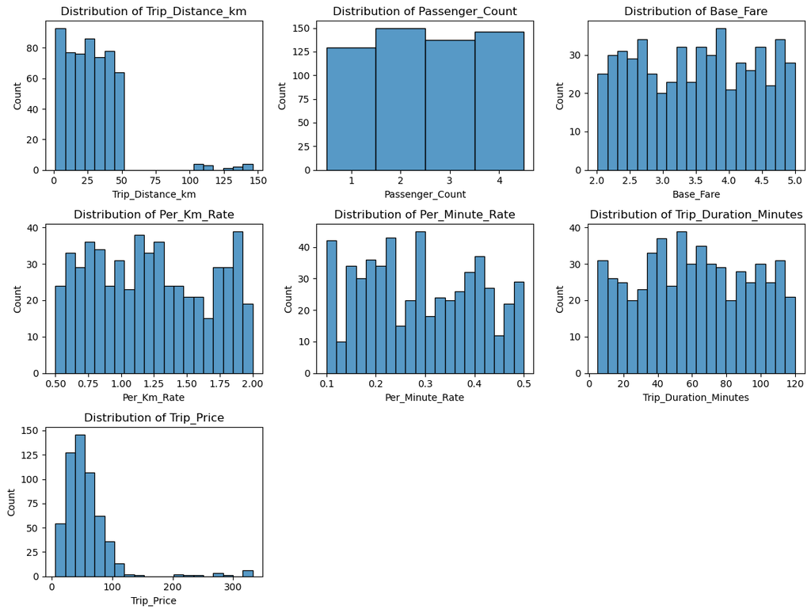

```python
num_cols = df.select_dtypes(include='number').columns.tolist()
grid = PlotGrid(len(num_cols))
for i, feature in enumerate(num_cols):
    axis = grid.get_axis(i)
    sns.histplot(
        data=df,
        x=feature,
        ax=axis,
        bins = 20,
        # Passenger_Count is integer so display as such
        discrete = feature=='Passenger_Count',
    )
    axis.set_title(f'Distribution of {feature}')

grid.show()
```

It is evident that the feature `Trip_Distance_km` and the target exhibit right-skewed distributions with several extreme high values. The remaining numerical features appear to have more uniform distributions. The presence of these outliers in the target and `Trip_Distance_km` feature suggests that a transformation of the skewed data may be necessary to improve model performance.

### Scatterplots of features vs target

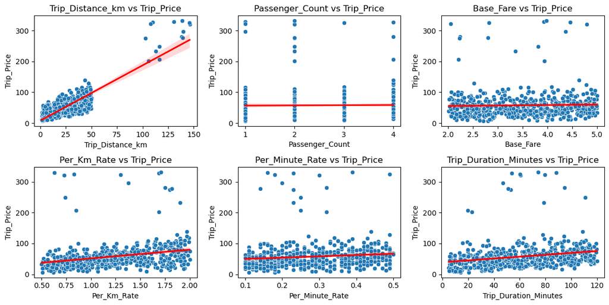

```python
X_num = df.copy()[num_cols]
target = X_num.pop("Trip_Price")
grid = PlotGrid(len(X_num.columns))

for i, feature in enumerate(X_num.columns):
    axis = grid.get_axis(i)
    sns.scatterplot(x=X_num[feature], y=target, ax=axis)
    sns.regplot(x=X_num[feature], y=target, scatter=False, color='red', ax=axis)
    axis.set_title(f"{feature} vs Trip_Price")
    axis.set_xlabel(feature)
    axis.set_ylabel('Trip_Price')
    # Passenger_Count axis labels should be integer
    if feature == 'Passenger_Count':
        axis.xaxis.set_major_locator(MaxNLocator(integer=True))
grid.show()
```

It is evident that the extreme values of the target correspond with the extreme values of `Trip_Distance_km`. However, there is also evidence of non-linearity in the relationship between these two. It may improve model performance if we transform either `Trip_Distance_km` or `Trip_Price`. Both are right skewed so we will investigate log, square-root and Box-Cox transformations. There doesn't appear to be any relationship between the extreme target values and other features.

### Categorical feature counts

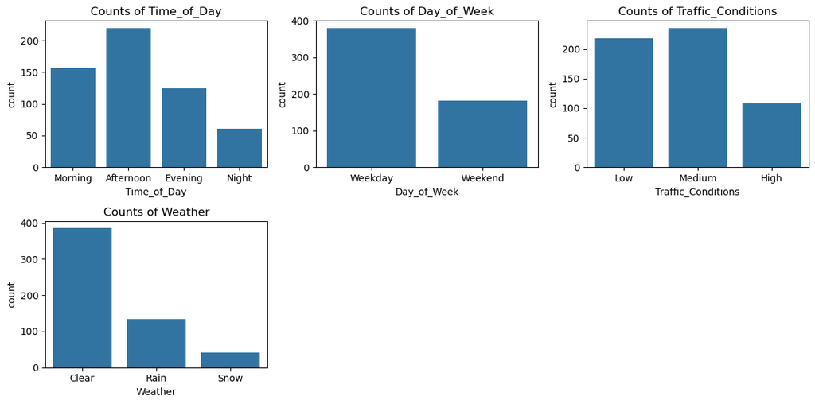

```python
grid = PlotGrid(len(cat_cols))

# two features have a natural order to the categories
category_orders = {
    'Time_of_Day': ['Morning', 'Afternoon', 'Evening', 'Night'],
    'Traffic_Conditions': ['Low', 'Medium', 'High'],
}
for i, feature in enumerate(cat_cols):
    axis = grid.get_axis(i)
    sns.countplot(
        data=df,
        x=feature,
        ax=axis,
        order=category_orders.get(feature),
    )
    axis.set_title(f'Counts of {feature}')

grid.show()
```

An examination of the categorical features reveals they all have low cardinality, with the most imbalanced being `Weather`. The smallest number of observations for `Weather` is **Snow**, which accounts for approximately 7.4%. In order to apply a Linear Regression to this dataset we need to encode the categorical features. Given this low cardinality and the relatively balanced distribution of categories, One-Hot Encoding is an appropriate choice for encoding.

## Evaluation of feature and target transformations

This section focuses on the evaluation of various data transformations to improve the performance of a Linear Regression model. Given the right-skewed nature of the target variable `Trip_Price` and `Trip_Distance_km`, we will investigate the effect of applying Log, Square Root, and Box-Cox transformations to each. By fitting and scoring a linear regression model for every pairwise combination of these transformations, plus the original untransformed data, we aim to identify the optimal configuration for predictive accuracy. The results are presented in the following table, which highlights the combination that yielded the best performance.

```python
# transformations to be applied to 'Trip_Distance_km'
log_transformer = Pipeline([
    ('log', FunctionTransformer(func=np.log1p, inverse_func=np.exp)),
    ('scaler', StandardScaler())
])

sqrt_transformer = Pipeline([
    ('sqrt', FunctionTransformer(func=np.sqrt, inverse_func=np.square)),
    ('scaler', StandardScaler())
])

boxcox_transformer = Pipeline([
    ('boxcox', PowerTransformer(method='box-cox')),
    ('scaler', StandardScaler()),
])

# transformations to be applied to target
log_target_regressor = TransformedTargetRegressor(regressor=LinearRegression(),
    func=np.log1p,
    inverse_func=np.expm1)

sqrt_target_regressor = TransformedTargetRegressor(regressor=LinearRegression(),
    func=np.sqrt,
    inverse_func=np.square)

boxcox_target_regressor = TransformedTargetRegressor(regressor=LinearRegression(),
    transformer=PowerTransformer(method='box-cox'))

X = df.copy()
y = X.pop('Trip_Price')
# holdout split for evaluation of final models
X_train, X_test, y_train, y_test = train_test_split(X, y, random_state=42)

# Trip_Distance_km is scaled in the transformation pipeline
num_features = X.select_dtypes(include='number').columns.tolist()
scale_cols = num_features.copy()
scale_cols.remove('Trip_Distance_km')

transformation_scores = []
for transform_name, feature_transformation in [('None', StandardScaler()), ('log', log_transformer),
                                               ('sqrt', sqrt_transformer),
                                               ('Box-cox', boxcox_transformer)]:
    for regressor_name, target_regressor in [('None', LinearRegression()),
                                             ('log', log_target_regressor),
                                             ('sqrt', sqrt_target_regressor),
                                             ('Box-cox', boxcox_target_regressor)]:
        preprocessor = ColumnTransformer([
            ('trip_dist', feature_transformation, ['Trip_Distance_km']),
            ('scaled', StandardScaler(), scale_cols),
            ('encoder', OneHotEncoder(drop='first', dtype=int, sparse_output=False), cat_cols)]
            ).set_output(transform="pandas") # output DataFrame with meaningful column names

        pipeline = Pipeline([
            ('preprocessor', preprocessor),
            ('regression', target_regressor),
        ])
        r2_mean, r2_std = score_model(X_train, y_train, pipeline)

        transformation_scores.append((transform_name, regressor_name, r2_mean, r2_std))

# convert score to DataFrame for better presentation
transformation_scores_df = pd.DataFrame(transformation_scores, columns=['Trip_Distance_km transformation',
    'Target transformation', 'Mean R-squared', 'R-squared std'])
display(Markdown('''#### Cross-validated linear regression scores'''))

# the row with the largest R2 value will be highlighted
best_row_index = transformation_scores_df['Mean R-squared'].idxmax()

def highlight_row_by_index(row):
    """
    Highlights a row if its index matches the best_row_index.
    """
    if row.name == best_row_index:
        return [f'background-color: {orange}'] * len(row)
    else:
        return [''] * len(row)

transformation_scores_df = transformation_scores_df.style.apply(highlight_row_by_index, axis=1).hide(
    axis="index")
display(transformation_scores_df)
```

Cross-validated linear regression scores

| Trip_Distance_km transformation | Target transformation | Mean R-squared | R-squared std |
| --- | --- | --- | --- |
| None | None | 0.873332 | 0.035067 |
| None | log | 0.211880 | 0.769314 |
| None | sqrt | 0.943050 | 0.021464 |
| None | Box-cox | 0.553628 | 0.421717 |
| log | None | 0.530539 | 0.060716 |
| log | log | 0.668729 | 0.083794 |
| log | sqrt | 0.618355 | 0.064593 |
| log | Box-cox | 0.663007 | 0.080967 |
| sqrt | None | 0.703597 | 0.056283 |
| sqrt | log | 0.883980 | 0.049027 |
| sqrt | sqrt | 0.820524 | 0.060446 |
| sqrt | Box-cox | 0.885711 | 0.055794 |
| Box-cox | None | 0.654403 | 0.062706 |
| Box-cox | log | 0.845928 | 0.080123 |
| Box-cox | sqrt | 0.765828 | 0.067056 |
| Box-cox | Box-cox | 0.838093 | 0.079509 |

The best scoring combination of feature and target transformations, as measured by cross validation on the training data is leaving the`Trip_Distance_km` untransformed and applying the square root transformation to the target, as highlighted in the table. However, the standard errors and difference in R2 mean suggest that the difference may not be significant. To determine the significance of this result we will evaluate this model on the test data and perform a T-test, comparing the errors of the linear regression model with transformed target with the errors of the base linear regression.

```python
base_preprocessor = ColumnTransformer([
    ('scaled', StandardScaler(), num_features),
    ('encoder', OneHotEncoder(drop='first', dtype=int, sparse_output=False), cat_cols)]
    ).set_output(transform="pandas")
base_pipeline = Pipeline([
    ('preprocessor', base_preprocessor),
    ('regression', LinearRegression()),
    ])
base_pipeline.fit(X_train, y_train)

# for significance test
pred_base = base_pipeline.predict(X_test)  # predictions of target
se_base = (y_test - pred_base) ** 2.       # squared errors
base_score = base_pipeline.score(X_test, y_test)  # R2 evaluated on test set

sqrt_pipeline = Pipeline([
            ('preprocessor', base_preprocessor),
            ('regression', sqrt_target_regressor),
        ])
sqrt_pipeline.fit(X_train, y_train)

pred_sqrt = sqrt_pipeline.predict(X_test)
se_sqrt = (y_test - pred_sqrt) ** 2
sqrt_score = sqrt_pipeline.score(X_test, y_test)

# we want the p_value of the T-test
t_stat, p_value = stats.ttest_rel(se_base, se_sqrt)

sqrt_scores_df = pd.DataFrame([(base_score, sqrt_score, p_value)], columns=['Base R-squared',
    'Sqrt(target) R-squared', 'T-test p-value'])
display(Markdown('''#### Significance test'''))
display(sqrt_scores_df.style.hide(axis="index"))
```

Significance test

| Base R-squared | Sqrt(target) R-squared | T-test p-value |
| --- | --- | --- |
| 0.898605 | 0.938476 | 0.165300 |

The p-value of the T-test for the differences between these models is non-significant at the 5% level. Therefore there's no evidence that square-root transformation of the target improves model performance so we will proceed with the base model (no transformations of `Trip_Distance_km` or target) which performs as well as any other and benefits from easier interpretation.  
There is, however, evidence of non-linearity between `Trip_Distance_km` and `Trip_Price` - the extreme values seem to lie mostly above the regression line. It is possible that the model could benefit from a quadratic term for `Trip_Distance_km`. Next we will add a quadratic `Trip_Distance_km` term and evaluate the model.

## Evaluation of a linear model with quadratic distance feature

```python
trip_distance_pipeline = Pipeline(steps=[
    # This step adds a quadratic term and preserves the original term
    ('poly', PolynomialFeatures(degree=2, include_bias=False)),
    # Standard scale the original and quadratic column
    ('scaler', StandardScaler())
    ])

quad_preprocessor = ColumnTransformer([
    ('quad', trip_distance_pipeline, ['Trip_Distance_km']),
    ('scaled', StandardScaler(), scale_cols),
    ('encoder', OneHotEncoder(drop='first', dtype=int, sparse_output=False), cat_cols)]
    ).set_output(transform="pandas")

quadratic_pipeline = Pipeline([
    ('preprocessor', quad_preprocessor),
    ('regression', LinearRegression()),
])

quad_scores = score_model(X_train, y_train, quadratic_pipeline)
quadratic_pipeline.fit(X_train, y_train)

pred_quad = quadratic_pipeline.predict(X_test)
se_quad = (y_test - pred_quad) ** 2
t_stat, p_value = stats.ttest_rel(se_base, se_quad)

val_score = quadratic_pipeline.score(X_test, y_test)

quad_scores_df = pd.DataFrame([quad_scores + (val_score, p_value)], columns=[
    'Cross validated R-squared mean',
    'Cross validated R-squared std', 'Validation R-squared', 'T-test p-value'])
display(Markdown('''#### Quadratic model scores'''))
display(quad_scores_df.style.hide(axis="index"))
```

Quadratic model scores

| Cross validated R-squared mean | Cross validated R-squared std | Validation R-squared | T-test p-value |
| --- | --- | --- | --- |
| 0.932778 | 0.019108 | 0.940039 | 0.072972 |

The addition of a quadratic term `Trip_Distance_km`<sup>2</sup> has improved model performance in terms of cross-validated R<sup>2</sup> mean and test R<sup>2</sup>, in relation to the base model but, as seen in the previous section, the difference is not significant.

```python
# Using the OLS model which provides more detailed statistical analysis
# transform the dataset (scaling, one hot encoding) so it can be used by OLS
X_train_transformed = base_pipeline.named_steps['preprocessor'].fit_transform(X_train)
# OLS requires an intercept term
X_train_transformed = sm.add_constant(X_train_transformed, prepend=True)
ols_model = sm.OLS(y_train, X_train_transformed)
baseline_results = ols_model.fit()

def highlight_p_value(val):
    """
    Highlights the cell if the p-value is > 0.05.
    """
    colour = orange if val > 0.05 else None
    return f'background-color: {colour}'

baseline_results_df = pd.DataFrame({'Coeff': baseline_results.params, 'P-value': baseline_results.pvalues}
        ).sort_values(by='Coeff', ascending=False, key=abs)

vifs = [variance_inflation_factor(X_train_transformed.values, i) for i in range(1, X_train_transformed.shape[1])]

baseline_results_df['VIF'] =  pd.Series([np.nan] + vifs, index=X_train_transformed.columns)
cleaned_index_names = clean_feature_names(baseline_results_df.index)
baseline_results_df.index = cleaned_index_names
baseline_results_df = baseline_results_df.style.format({'P-value': '{:.4f}'}).map(
    highlight_p_value,
    subset=['P-value']
)

display(Markdown('''## Evaluation of baseline linear regression model'''))
display(baseline_results_df)
```

Evaluation of baseline linear regression model

|  | Coeff | P-value | VIF |
| --- | --- | --- | --- |
| const | 60.357561 | 0.0000 | nan |
| Trip_Distance_km | 35.478013 | 0.0000 | 1.031955 |
| Per_Km_Rate | 10.851488 | 0.0000 | 1.019094 |
| Trip_Duration_Minutes | 9.621541 | 0.0000 | 1.038505 |
| Per_Minute_Rate | 7.001665 | 0.0000 | 1.023149 |
| Traffic_Conditions_Medium | -4.444872 | 0.0254 | 1.908129 |
| Traffic_Conditions_Low | -4.434886 | 0.0280 | 1.899307 |
| Time_of_Day_Morning | 2.144790 | 0.2232 | 1.267837 |
| Time_of_Day_Evening | -1.714469 | 0.3693 | 1.248292 |
| Day_of_Week_Weekend | 1.428876 | 0.3521 | 1.033264 |
| Weather_Rain | -1.251168 | 0.4654 | 1.073055 |
| Weather_Snow | 1.059856 | 0.6946 | 1.047856 |
| Passenger_Count | -0.625714 | 0.3867 | 1.039226 |
| Time_of_Day_Night | -0.602792 | 0.8108 | 1.157404 |
| Base_Fare | -0.109926 | 0.8787 | 1.033408 |

We can see from the model metrics that there are no problematic VIFs, so no indication of multicollinearity. There are 4 features with highly significant p-values, `Trip_Distance_km`, `Per_Km_Rate`, `Trip_Duration_Minutes` and `Per_Minute_Rate`. There are also `Traffic_Conditions` features which although are significant at the 5% level, are not significant at the 1% level, so it's not clear if these features are truly important. There are 8 coefficients which have non-significant p-values (highlighted), which suggests a high degree of redundancy in the baseline model. We will now employ some regularized models in order to address feature insignificance and possibly improve model performance.

## Regularized linear models

In this section we will tune and evaluate these 3 regularized linear models. We will tune hyperparameters using grid search with cross-validation;

- Ridge - shrinks the coefficients toward zero to improve model stability (the coefficients of the less important features are shrunk more)
- Lasso - shrinks the coefficients of less important features all the way to zero, thereby performing automatic feature selection
- Elastic Net - a blend of Ridge and Lasso

```python
# First we use RidgeCV, LassoCV, ElasticNetCV to find the best alpha, l1_ratio
# then cross validate using those values

regularized_regressors = {
    'Ridge': (RidgeCV(alphas=[0, 0.01, 0.1, 1, 10, 15], cv=5, scoring='r2'),
                                    Ridge()),
    'Lasso': (LassoCV(alphas=[0, 0.01, 0.1, 0.5, 1.0], cv=5, random_state=42, max_iter=5000),
        Lasso()),
    'ElasticNet': (ElasticNetCV(alphas=[0, 0.01, 0.1, 0.5, 1.0],
                                l1_ratio = [0, 0.1, 0.5, 0.9, 1], cv=5,
            random_state=42, max_iter=5000),
        ElasticNet())}

reg_model_scores = []
best_reg_models = {}
for reg_name, regressors in regularized_regressors.items():
    cv_regressor, base_regressor = regressors
    cv_pipeline = Pipeline([
        ('preprocessor', base_preprocessor),
        ('model', cv_regressor),
    ])
    cv_pipeline.fit(X_train, y_train)

    # get the best model from cv_pipeline
    best_regressor = cv_pipeline.named_steps['model']
    best_alpha = best_regressor.alpha_

    # set the optimum hyperparameters
    base_regressor.set_params(alpha = best_alpha)

    # only ElasticNet has l1_ratio
    try:
        l1_ratio = best_regressor.l1_ratio_
        base_regressor.set_params(l1_ratio = best_regressor.l1_ratio_)
    except AttributeError:
        l1_ratio = None

    plain_pipeline = Pipeline([
        ('preprocessor', base_preprocessor),
        ('model', base_regressor),
    ])
    # get cross validated scores
    r2_mean, r2_std = score_model(X_train, y_train, plain_pipeline)
    reg_model_scores.append((reg_name, best_alpha, l1_ratio, r2_mean, r2_std))

    best_reg_models[reg_name] = plain_pipeline

reg_scores_df = pd.DataFrame(reg_model_scores)
reg_scores_df.columns = ['Regressor', 'alpha', 'L1 ratio', 'Mean R-squared', 'R-Squared std']
best_row_index = reg_scores_df['Mean R-squared'].idxmax()
display(reg_scores_df.style.hide(axis="index").format({'alpha': "{:,.2f}", 'L1 ratio': "{:,.1f}"}
     ).apply(highlight_row_by_index, axis=1))
```

| Regressor | alpha | L1 ratio | Mean R-squared | R-Squared std |
| --- | --- | --- | --- | --- |
| Ridge | 10.00 | nan | 0.874691 | 0.037259 |
| Lasso | 0.50 | nan | 0.876739 | 0.035878 |
| ElasticNet | 0.50 | 1.0 | 0.876739 | 0.035878 |

```python
reg_val_scores = []
for name, reg_model in best_reg_models.items():
    reg_model.fit(X_train, y_train)
    pred_ = reg_model.predict(X_test)
    se_ = (y_test - pred_) ** 2
    val_score = reg_model.score(X_test, y_test)
    t_stat, p_value = stats.ttest_rel(se_base, se_)
    reg_val_scores.append((name, val_score, p_value))
reg_val_scores_df = pd.DataFrame(reg_val_scores)
reg_val_scores_df.columns = ['Regressor', 'R-squared', 'P-value']

display(reg_val_scores_df.style.hide(axis="index").format({'alpha': "{:,.2f}",
    'l1_ratio': "{:,.1f}"}))
```

| Regressor | R-squared | P-value |
| --- | --- | --- |
| Ridge | 0.895785 | 0.412265 |
| Lasso | 0.897391 | 0.697853 |
| ElasticNet | 0.897391 | 0.697853 |

It is clear while that none of the regularized models are better than the base linear regression, they are not significantly worse either. Since Lasso regression reduces some coefficients to exactly zero, it will be interesting to examine the reduced feature set which Lasso provides.

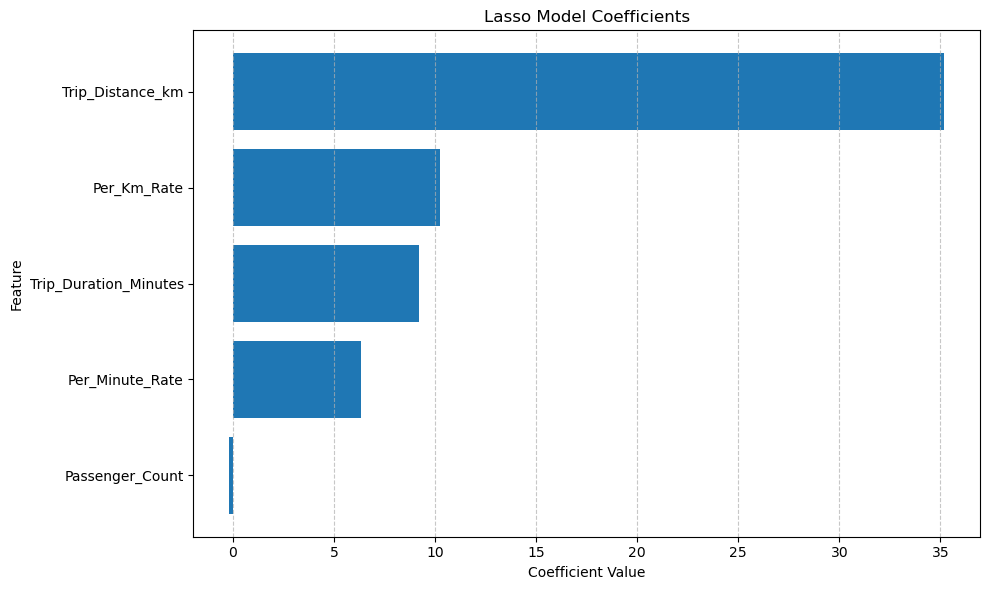

```python
lasso_pipeline = best_reg_models.get('Lasso')
best_lasso = lasso_pipeline.named_steps['model']
feature_names = lasso_pipeline.named_steps['preprocessor'].get_feature_names_out()
# Create a DataFrame for presentation
coef_df = pd.DataFrame({
    'feature': clean_feature_names(feature_names),
    'coefficient': best_lasso.coef_,
})

non_zero_coefs = coef_df[coef_df['coefficient'] != 0].copy()

# Sort the DataFrame in descending order by coefficient value
sorted_coefs = non_zero_coefs.sort_values(by='coefficient', ascending=True)

# Plot the horizontal bar plot
plt.figure(figsize=(10, 6))
plt.barh(sorted_coefs['feature'], sorted_coefs['coefficient'], color=blue)
plt.xlabel('Coefficient Value')
plt.ylabel('Feature')
plt.title('Lasso Model Coefficients')
plt.grid(axis='x', linestyle='--', alpha=0.7)
plt.tight_layout()
```

Lasso regression has effectively reduced the model to 5 meaningful predictors while offering a comparable performance to the baseline linear regression model. Next we will evaluate tree-based models.

## Tree-based models

In this section we will evaluate 3 tree based regression models, Decision Tree, Random Forest and XGBoost

### Decision Tree

Decision Tree is the simplest tree based model. It builds a single tree and is the fundamental building block of all tree based models. The Decision Tree algorithm is not sensitive to feature scaling so we can drop the scaling step from the preprocessor without affecting model performance.

```python
# tree based models don't require scaling
tree_preprocessor = ColumnTransformer([
    ('encoder', OneHotEncoder(drop='first', dtype=int, sparse_output=False), cat_cols)],
        remainder='passthrough',
        force_int_remainder_cols=False
        ).set_output(transform="pandas")

decision_tree_pipeline = Pipeline([
    ('preprocessor', tree_preprocessor),
    ('regression', DecisionTreeRegressor(random_state=42)),
])

# we will use grid search to find optimum hyperparameters
dt_param_grid = {
    'regression__max_depth': [3, 10, 20],  # None = unlimited
    'regression__min_samples_split': [2, 3, 5],
    'regression__min_samples_leaf': [3, 4, 5, 10],
}
dt_grid_search = GridSearchCV(
    estimator=decision_tree_pipeline,
    param_grid=dt_param_grid,
    cv=5,
    scoring='r2',
    n_jobs=-1       # Use all cores to speed it up
)

dt_grid_search.fit(X_train, y_train)

# get the best model
best_dt_model = dt_grid_search.best_estimator_
# get the cross validated R2 scores
dt_scores  = score_model(X_train, y_train, dt_grid_search)

# test the significance of model performance vs the base linear regression model
pred_dt = best_dt_model.predict(X_test)
se_dt = (y_test - pred_dt) ** 2
val_score = best_dt_model.score(X_test, y_test)
t_stat, p_value = stats.ttest_rel(se_base, se_dt)
dt_scores_df = pd.DataFrame([dt_scores + (val_score, p_value)], columns=['Cross validated R-squared mean',
    'Cross validated R-squared std', 'Validation R-squared', 'T-test p-value'])
display(Markdown('''#### Scores'''))
display(dt_scores_df.style.hide(axis="index"))

def display_hyperparameters(params, title = "Optimum Hyperparameters"):
    display(Markdown(f'''#### {title}'''))
    params_df=pd.DataFrame.from_dict(params, orient='index',
        dtype='object')
    cleaned_indices = clean_feature_names(params_df.index)
    params_df.index = cleaned_indices
    display(params_df.style.hide(axis="columns"))

display_hyperparameters(dt_grid_search.best_params_)
```

Scores

| Cross validated R-squared mean | Cross validated R-squared std | Validation R-squared | T-test p-value |
| --- | --- | --- | --- |
| 0.906635 | 0.036028 | 0.941615 | 0.168838 |

Optimum Hyperparameters

| max_depth | 10 |
| --- | --- |
| min_samples_leaf | 4 |
| min_samples_split | 2 |

It is evident that the Decision Tree regression has not performed significantly better than the base model  
This could be because a linear model, by definition, produces a smooth, continuous output, which is often a better fit for this kind of data than the 'stepped' output of a tree based regression. Also decision trees are known for their poor extrapolation capabilities, which could have been exacerbated by the handful of extreme values in this data (if a training split contained few or no extreme values then the predictions on the test split would be bad). It is limitations such as these which lead to the development of ensemble techniques such as Random Forest, which we will discuss in the next section.

### Random Forest

Random Forest is an ensemble learning method which combines the predictions of many decision trees to produce a prediction which is the average of the individual trees. Random Forest models are generally more robust and produce more accurate predictions than simple decision trees. We will fit a Random Forest model to the data.

```python
random_forest_pipeline = Pipeline([
    ('preprocessor', tree_preprocessor),
    ('regression', RandomForestRegressor(random_state=42, n_jobs=-1)),
])

# initially use randomized search over a wide range of values
rf_param_distributions = {
    'regression__n_estimators': stats.randint(50, 500),        # Wide range for number of trees
    'regression__max_features': ['sqrt', 'log2', None],        # Common choices for max_features
    'regression__max_depth': stats.randint(5, 30),             # Wide range for depth
    'regression__min_samples_split': stats.randint(2, 20),     # Range for splitting
    'regression__min_samples_leaf': stats.randint(1, 20),      # Range for leaves
    'regression__bootstrap': [True, False]                     # Whether to use bootstrap samples
}
rf_random_search = RandomizedSearchCV(
    estimator=random_forest_pipeline,
    param_distributions=rf_param_distributions,
    n_iter=100,
    cv=3,         # Use fewer folds to speed up the initial search
    scoring='r2',
    random_state=42,
    n_jobs=-1
)
rf_random_search.fit(X_train, y_train)
display_hyperparameters(rf_random_search.best_params_,
    title="Optimum Hyperparameters from Randomized Search")
```

Optimum Hyperparameters from Randomized Search

| bootstrap | True |
| --- | --- |
| max_depth | 17 |
| max_features | None |
| min_samples_leaf | 3 |
| min_samples_split | 10 |
| n_estimators | 335 |

```python
# use best_params from randomized search as a starting point for a focused grid search
focused_rf_param_grid = {
    'regression__n_estimators': [175, 200, 225],
    'regression__max_depth': [16, 17, 18, 19],
    'regression__max_features': [None],
    'regression__min_samples_leaf': [2, 3, 4],
    'regression__min_samples_split': [2, 3, 5, 10, 15],
    'regression__bootstrap': [True],
}
rf_focused_search = GridSearchCV(
    estimator=random_forest_pipeline,
    param_grid=focused_rf_param_grid,
    cv=5,   # revert to 5 fold now we're fine tuning
    scoring='r2',
    n_jobs=-1
)

rf_focused_search.fit(X_train, y_train)

# get the best model from grid search
best_rf = rf_focused_search.best_estimator_


pred_rf = best_rf.predict(X_test)   # predicted target from X_test
se_rf = (y_test - pred_rf) ** 2     # errors from random forest model

# Perform a paired t-test on the errors
t_stat, rf_p_value = stats.ttest_rel(se_base, se_rf)

rf_scores  = score_model(X_train, y_train, best_rf)
rf_scores_df = pd.DataFrame([rf_scores + (best_rf.score(X_test, y_test), rf_p_value)],
    columns=['Cross validated R-squared mean', 'Cross validated R-squared std',
    'Validation R-squared', 'T-test p-value'])
display(Markdown('''#### Scores'''))
display(rf_scores_df.style.hide(axis="index"))

display_hyperparameters(rf_focused_search.best_params_)
```

Scores

| Cross validated R-squared mean | Cross validated R-squared std | Validation R-squared | T-test p-value |
| --- | --- | --- | --- |
| 0.939824 | 0.028975 | 0.961572 | 0.082057 |

Optimum Hyperparameters

| bootstrap | True |
| --- | --- |
| max_depth | 18 |
| max_features | None |
| min_samples_leaf | 3 |
| min_samples_split | 3 |
| n_estimators | 200 |

The Random Forest model with 200 estimators (trees) and max_depth of 18 (maximum number of splits) appears to perform better than previous models but once again the difference is not statistically significant.

### XGBoost

While a Random Forest builds a large number of independent trees and averages their predictions, XGBoost takes a sequential approach, building trees one after the other, where each new tree is specifically designed to correct the mistakes of the previous ones. XGBoost is one of the best-performing algorithms for tabular data such as the taxi trip pricing dataset.

```python
xgb_model = xgb.XGBRegressor(enable_categorical=True,
    tree_method='hist', # both required for categorical data
    random_state=42)

# We need to set aside an evaluation dataset for early stopping
X_train_, X_val, y_train_, y_val = train_test_split(X_train, y_train, test_size=0.2,
    random_state=42)

# start with a wide range for each hyperparameter and use Randomized Search
xgb_param_distributions = {
    'n_estimators': randint(200, 1500),
    'learning_rate': uniform(0.01, 0.3),
    'max_depth': randint(3, 12),
    'subsample': uniform(0.6, 0.4),
    'colsample_bytree': uniform(0.6, 0.4),
    'gamma': uniform(0, 5),
    'early_stopping_rounds': randint(40, 60),
}
xgb_random_search = RandomizedSearchCV(
    estimator=xgb_model,
    param_distributions=xgb_param_distributions,
    n_iter=100,
    cv=3,        # Using fewer folds for speed
    scoring='r2',
    random_state=42,
    n_jobs=-1
)

xgb_random_search.fit(
    X_train_,
    y_train_,
    eval_set=[(X_val, y_val)],
    verbose=False,
)
display_hyperparameters(xgb_random_search.best_params_,
    title = "Optimium Hyperparameters from Randomized Search")
```

Optimium Hyperparameters from Randomized Search

| colsample_bytree | 0.958083 |
| --- | --- |
| early_stopping_rounds | 53.000000 |
| gamma | 3.748081 |
| learning_rate | 0.019142 |
| max_depth | 4.000000 |
| n_estimators | 1005.000000 |
| subsample | 0.813047 |

```python
# use best_params_ from randomized search as a basis for a more focused grid search
focused_xgb_param_grid = {
    'n_estimators': [500, 750, 1000],
    'learning_rate': [0.01, 0.02, 0.05],
    'max_depth': [3, 4, 5],
    'subsample': [0.5, 0.6, 0.8],
    'colsample_bytree': [ 0.9, 0.95, 1],
    'gamma': [3, 4, 5],
    'early_stopping_rounds': [50, 53, 60],
}
xgb_grid_search = GridSearchCV(
    estimator=xgb_model,
    param_grid=focused_xgb_param_grid,
    cv=5,
    scoring='r2',
    n_jobs=-1
)
xgb_grid_search.fit(
    X_train_,
    y_train_,
    eval_set=[(X_val, y_val)],
    verbose=False,
)

best_xgb = xgb_grid_search.best_estimator_
final_params = xgb_grid_search.best_params_.copy()
# we can get optimum n_estimators from best_xgb.best_iteration
final_params.pop('n_estimators')
final_params.pop('early_stopping_rounds') # no longer relevant

final_xgb = xgb.XGBRegressor(
    enable_categorical=True,
    tree_method='hist', # both required for categorical data
    random_state=42,
    **final_params,
    n_estimators=best_xgb.best_iteration
)
xgb_scores  = score_model(X_train, y_train, final_xgb)
final_xgb.fit(X_train, y_train)
pred_xgb = final_xgb.predict(X_test)
se_xgb = (y_test - pred_xgb) ** 2

# Perform a paired t-test on the errors
t_stat, xgb_p_value = stats.ttest_rel(se_base, se_xgb)
xgb_scores_df = pd.DataFrame([xgb_scores + (final_xgb.score(X_test, y_test), xgb_p_value)],
    columns=['Cross validated R-squared mean', 'Cross validated R-squared std',
    'Validation R-squared', 'T-test p-value'])
display(Markdown('''#### Scores'''))
display(xgb_scores_df.style.hide(axis="index"))
xgb_results = {'Optimal number of trees': best_xgb.best_iteration}
xgb_results.update(final_params)
xgb_results_df = pd.DataFrame.from_dict(xgb_results, orient='index', dtype='object')

# format some rows
precision_dict = {
    'R2 mean': 6,
    'Optimal number of trees': 0,
    'max_depth': 0,
    'learning_rate': 3,
}
for idx, row in xgb_results_df.iterrows():
    n = precision_dict.get(idx, 1)
    xgb_results_df.loc[idx] = xgb_results_df.loc[idx].apply(lambda x: f"{x:.{n}f}")

display(Markdown('''#### Optimum Hyperparameters from Grid Search'''))
display(xgb_results_df.style.hide(axis="columns"))
```

Scores

| Cross validated R-squared mean | Cross validated R-squared std | Validation R-squared | T-test p-value |
| --- | --- | --- | --- |
| 0.933103 | 0.027152 | 0.960395 | 0.004600 |

Optimum Hyperparameters from Grid Search

| Optimal number of trees | 299 |
| --- | --- |
| colsample_bytree | 1.0 |
| gamma | 4.0 |
| learning_rate | 0.020 |
| max_depth | 4 |
| subsample | 0.5 |

The XGBoost model is significantly more accurate than the baseline Linear Regression model.

### Model Interpretation

#### Permutation Importance

Permutation importance estimates the importance of each feature by randomly shuffling the values for each feature then scoring the model using the shuffled feature and the remaining original features. The idea is that, if a feature is an important predictor, shuffling the values will have a detrimental effect on model performance, and the more important a feature is, the more the model performance will be harmed.

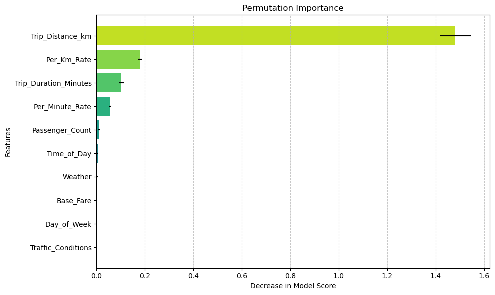

```python
# Use the test set to get a more robust measure of generalization
result = permutation_importance(
    estimator=final_xgb,
    X=X_train,
    y=y_train,
    n_repeats=10,  # Number of times to shuffle each feature
    random_state=42,
    n_jobs=-1,
)

# Create a DataFrame for easier plotting and interpretation
perm_importances = pd.DataFrame({
    "feature": X_train.columns,
    "importance_mean": result.importances_mean,
    "importance_std": result.importances_std,
    }).sort_values("importance_mean")

# Plotting Permutation Importance with error bars
plt.figure(figsize=(10, 6))
plt.barh(
    clean_feature_names(perm_importances["feature"]),
    perm_importances["importance_mean"],
    xerr=perm_importances["importance_std"],
    color=sns.color_palette("viridis", len(perm_importances)),
)
plt.title("Permutation Importance")
plt.xlabel(f"Decrease in Model Score")
plt.ylabel("Features")
plt.grid(axis='x', linestyle='--', alpha=0.7)
plt.tight_layout()
plt.show()
```

#### Partial Dependence plots

A partial dependence plot is a tool used to visualize the relationship between a single feature and the predicted outcome of a machine learning model, while averaging out the effects of all other features. It is analogous to a plot of a single coefficient in a multivariate linear regression.

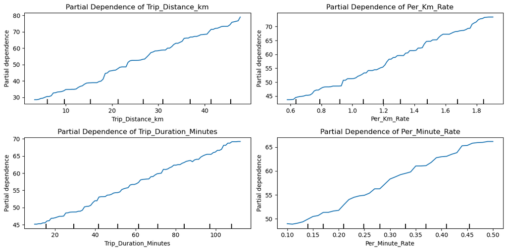

```python
# select the 4 most important features
important_features = perm_importances.sort_values("importance_mean", ascending=False).head(4)['feature']
grid = PlotGrid(len(important_features), n_cols=2)

for i, feature in enumerate(important_features):
    axis = grid.get_axis(i)
    pdd = PartialDependenceDisplay.from_estimator(
        final_xgb,
        X_train, [feature],
        ax=axis)

    axis.set_title(f'Partial Dependence of {feature}')

grid.show()
```

The partial dependence plots of `Trip_Distance_km`, `Per_Km_Rate`, `Trip_Duration_Minutes` and `Per_Minute_Rate` indicate that the relationships between these features and target are approximately linear ie a larger value for any of these predictors is associated with a higher predicted `Trip_Price`.

#### SHAP plots

SHAP (SHapley Additive exPlanations) is a machine learning technique that explains the output of any machine learning model. SHAP values assign an importance value to each feature in a model's prediction, showing how much each feature contributes to pushing the output from a base value (average output) to the final prediction for a specific instance.

#### Global Feature Importance

This plot summarises the average effect of each feature on predictions.

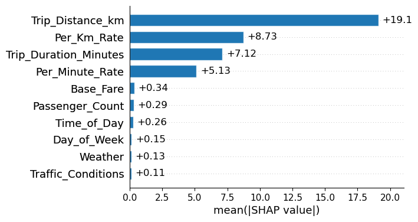

```python
# Calculate SHAP values
explainer = shap.Explainer(final_xgb)
shap_values = explainer(X_train)

# plot Global Feature Importance
fig, ax = plt.subplots(1,1, figsize=(6,4))
shap.plots.bar(shap_values, max_display=10, show=False, ax=ax)

# override default colours
# Iterate over the bars and set colour
for bar in ax.patches:
    bar.set_facecolor(blue)
# Iterate of number annotations and set colour
for text in ax.texts:
    text.set_color('black')

plt.show()
```

#### SHAP Summary plot

This plot illustrates the nature of the relationship between feature and target. Each point represents an observation of feature (with colour representing feature value) and impact on prediction (position on horizontal axis).

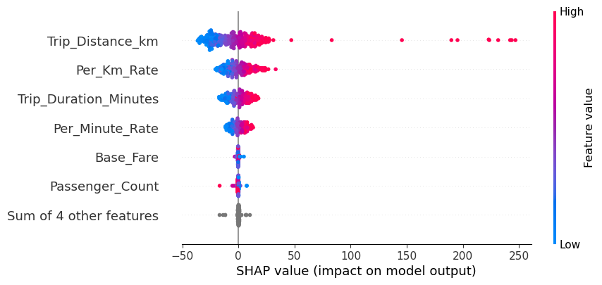

```python
shap.plots.beeswarm(shap_values, max_display=7)
```

For the 4 key features low values of feature generally correspond with negative impact on prediction and high values with positive impact on prediction. This broadly agrees with the relationships illustrated in the partial dependence plots.

#### 2-D Partial Dependence plots

A 2-D Partial Dependence plot is a visualization that illustrates the combined effect of two features on the predicted outcome of a machine learning model, while averaging out the effects of all other features.  
There are two obvious pairs of predictors of interest. `Trip_Distance_km` and `Per_Km_Rate` could be considered the 'Distance' features and `Trip_Duration_Minutes` and `Per_Minute_Rate` could be considered the 'Time' features. It could be interesting to examine 2-D partial dependence plots of these pairs.

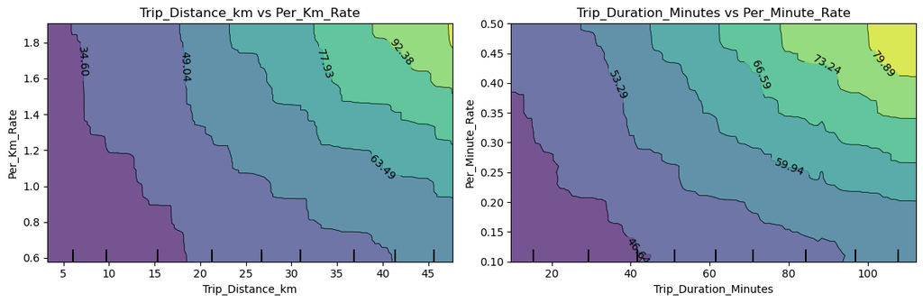

```python
feature_pairs = [
    ['Trip_Distance_km', 'Per_Km_Rate'],   # Distance Pair
    ['Trip_Duration_Minutes', 'Per_Minute_Rate'] # Duration Pair
]
grid = PlotGrid(len(feature_pairs), n_cols=2, row_height=4)
for i, pair in enumerate(feature_pairs):
    axis = grid.get_axis(i)
    feature_a, feature_b = pair
    pdd = PartialDependenceDisplay.from_estimator(
        final_xgb,
        X_train,
        features = [pair],
        ax=axis)
    pdd.axes_[0][0].set_xlabel(feature_a)
    pdd.axes_[0][0].set_ylabel(feature_b)
    axis.set_title(f'{feature_a} vs {feature_b}')

grid.show()
```

The plots of both pairs reveal interactions between the pair - the effect of one predictor is affected by the value of the other.  
One of the advantages of tree based models is that they can find these interactions by themselves, they are already incorporated into the models. This could explain why XGBoost performed better than linear models.  
In hindsight it seems that an interaction term such as `Trip_Duration_Minutes` x `Per_Minute_Rate` should be a useful predictor of `Trip_Price`, so may be worth updating the linear regression model to include the two interactions terms. This approach was tried but actually didn't improve performance and resulted in multicollinearity.

#### Residual analysis

The purpose of this analysis is to validate the model's adequacy by ensuring its errors are random and unsystematic, which would indicate that all main patterns in the data have been captured.

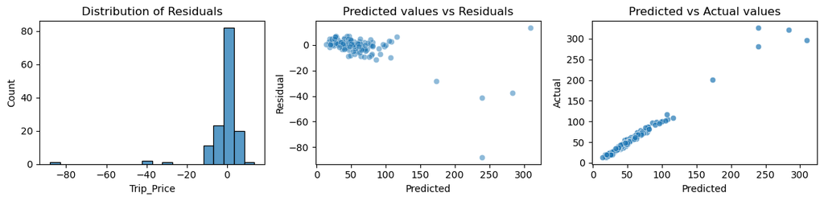

```python
residuals = pred_xgb - y_test

grid = PlotGrid(n_plots=3)
sns.histplot(residuals,
    ax=grid.get_axis(0),
    bins=20,
)
grid.get_axis(0).set_title('Distribution of Residuals')

sns.scatterplot(x=pred_xgb, y=residuals, alpha=0.5, ax=grid.get_axis(1))
grid.get_axis(1).set_ylabel('Residual')
grid.get_axis(1).set_xlabel('Predicted')
grid.get_axis(1).set_title('Predicted values vs Residuals')

sns.scatterplot(x=pred_xgb, y=y_test, alpha=0.7, ax=grid.get_axis(2))
grid.get_axis(2).set_title('Predicted vs Actual values')
grid.get_axis(2).set_ylabel('Actual')
grid.get_axis(2).set_xlabel('Predicted')
grid.show()
```

The residual plots consistently highlight the influence of 5 extreme values. While the residuals for the majority of predictions are randomly scattered, indicating a well-performing model for `Trip_Price` under 150, they exhibit significant heteroscedasticity. This is evidenced by a large increase in variance and error for higher-valued predictions, revealing the model's declining accuracy beyond the 150 `Trip_Price` point.

### Conclusion

This analysis successfully developed a robust predictive model for taxi trip prices using XGBRegressor. The model demonstrates strong performance for the vast majority of trips, accurately predicting prices within the common range.  
We used permutation importances to quantify the importance of each feature in predicting target values, partial dependence plots to show *how* the feature affects the predicted values and global SHAP values to quantify the effect of feature values on predicted values. While the presence of extreme high-value outliers limits precision at the upper end, the model's core functionality is validated by its good cross-validated scores (mean R-squared **0.933103**) and random residual pattern for the main body of data. Overall, this model provides a reliable basis for understanding and forecasting trip costs.